# Analisis

LCCM

2025-11-19

Objetivos general Hacer uso de los paquetes utilizados en clase, proponiendo una función que facilite un analisis

Objetivos específicos 1 Obtener secuencia ITS de Aspergillus 2 Hacer análisis de la secuencia alineamientos pra construir un árbol 3 Una función que al integrarle una secuencia la pueda integrar a lo ya presentado

Métodos Alineamiento múltiple de secuencias 1. Se realizó un alineamiento múltiple usando el paquete msa en R. El alineamiento resultante fue convertido a formato compatible con los datos necesarios para árboles filogeneticos  
2. Cálculo de distancias genéticas, Modelo K80 que es utilizado para hongos donde see estimaron distancias evolutivas entre pares de secuencias usando el modelo Kimura 2-Parameters 3. Construcción del árbol filogenético este con NJ (Neighbor-Joining) para construir el árbol filogenético 4. Hacer función con estos pasos anteriores además de la inclusión de la secuencia para determinar si es cercana a las secuencias qué tenemos entre otros análisis realizados

Resultado 1. Alineamiento múltiple Se obtuvo un alineamiento consistente entre todas las secuencias ITS analizadas, permitiendo calcular distancias genéticas comparables bajo el modelo K80. 2. Árbol filogenético El análisis NJ generó un árbol filogenético que mostró la agrupación de las especies del género Aspergillus según su similitud molecular. Las secuencias se organizaron en clados coherentes con relaciones evolutivas previamente reportadas. 3. Funcion integradora Se utilizaron los datos que se tenian para a una nueva secuencia alinearla y ver si esta esta relacionada

```r
library(Biostrings)   # Para manipulación de secuencias biológicas
library(msa)          # Para alineamiento múltiple (MUSCLE)
library(ape)          # Para análisis filogenético y construcción de árboles
library(ggmsa)        # Para visualización del alineamiento
```

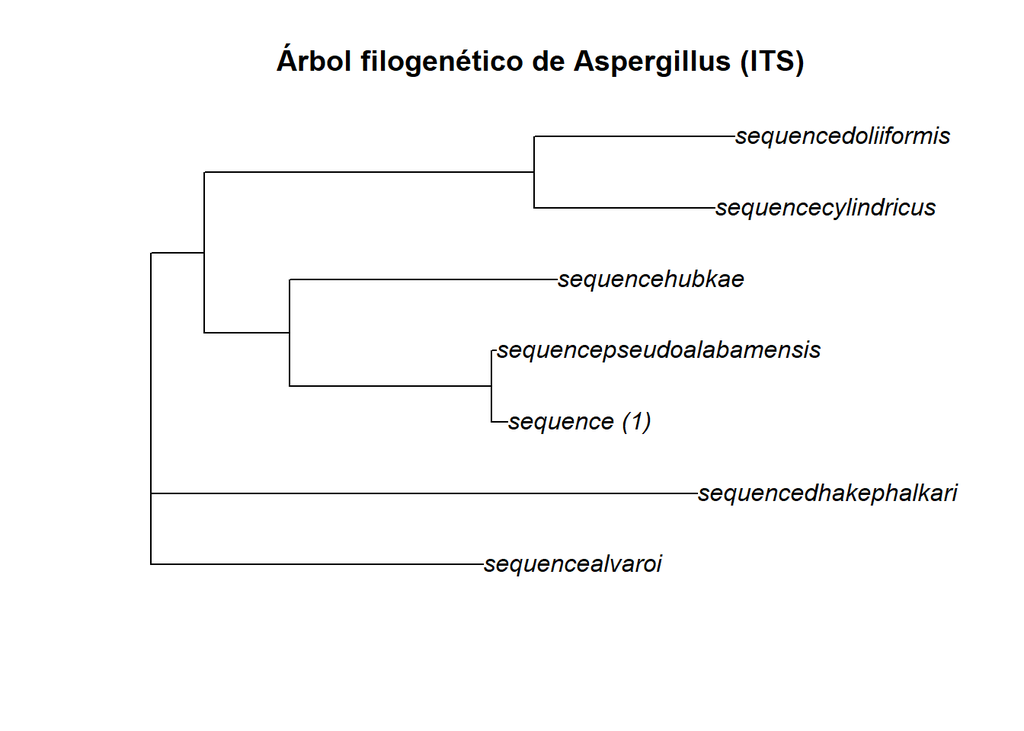

```r
setwd ("C:/Users/crism/Documents/proyecto final robert/prueba")

# Leer múltiples archivos FASTA de secuencias ITS y combinarlos
# (Ajustar el patrón o lista de archivos según su directorio de trabajo)
archivos <- list.files(pattern = "^sequence.*\\.fasta$")
secuencias_lista <- lapply(archivos, readDNAStringSet)
todas_secuencias <- do.call(c, secuencias_lista)
# Asignar nombres basados en el nombre de archivo (sin extensión)
names(todas_secuencias) <- sub("\\.fasta$", "", archivos)

# Alinear las secuencias combinadas usando MUSCLE
alineamiento <- msa(todas_secuencias, method = "Muscle")
# Convertir el alineamiento a formato compatible con ape (seqinr)
aline_seqinr <- msaConvert(alineamiento, type = "seqinr::alignment")
aline_dnabin <- as.DNAbin(aline_seqinr)


# Construir árbol filogenético (vecino más cercano - NJ) usando distancia genética (modelo K80)
distancias <- dist.dna(aline_dnabin, model = "K80")
arbol_filogenetico <- nj(distancias)
# Opcional: graficar el árbol filogenético
plot(arbol_filogenetico, main = "Árbol filogenético de Aspergillus (ITS)")
```

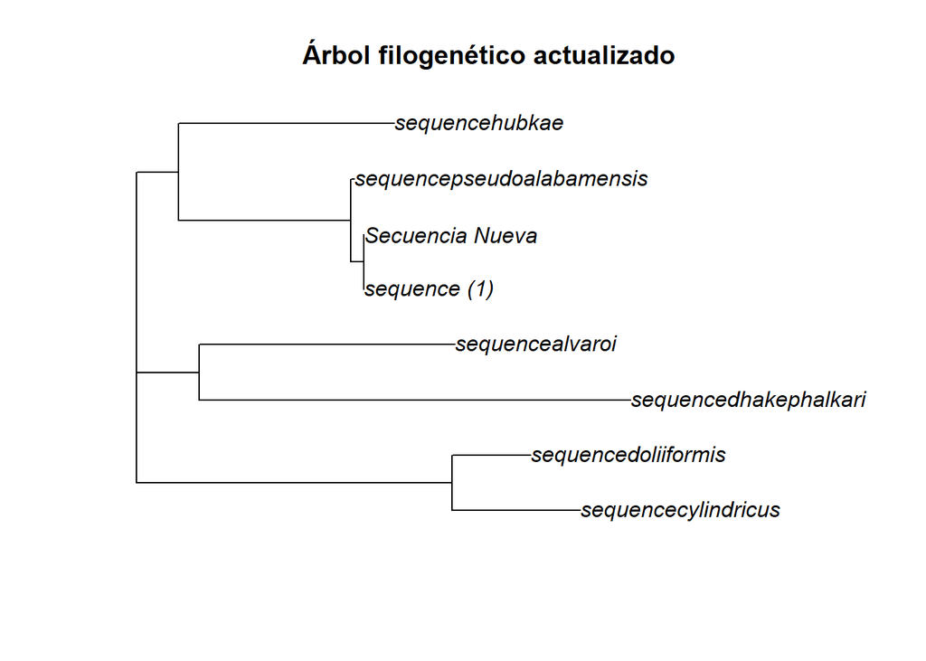

```
## La secuencia nueva es filogenéticamente más cercana a: sequence (1)
## Contenido GC (%): 59.73
## Conteo nucleótidos (A, C, G, T): 113 182 174 127
```

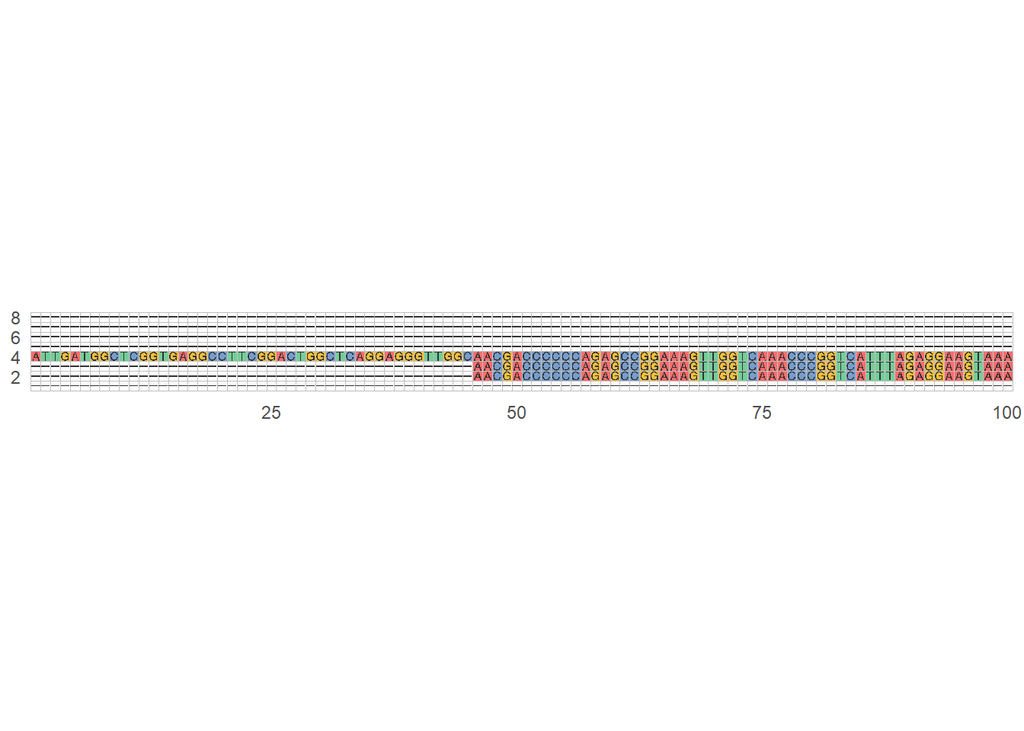

```r
# Función para agregar una nueva secuencia y actualizar el análisis
analizar_nueva_secuencia <- function(nueva_secuencia) {
  # Convertir la nueva secuencia a DNAStringSet y asignarle un nombre
  nueva_set <- DNAStringSet(nueva_secuencia)
  names(nueva_set) <- "Secuencia_Nueva"

  # Agregar la nueva secuencia al conjunto existente
  secuencias_actualizadas <- c(todas_secuencias, nueva_set)

  # Realizar nuevo alineamiento con todas las secuencias
  aline2 <- msa(secuencias_actualizadas, method = "Muscle")
  # Convertir a formato seqinr y DNAbin para ape
  aline2_seqinr <- msaConvert(aline2, type = "seqinr::alignment")
  aline2_dnabin <- as.DNAbin(aline2_seqinr)

  # Construir nuevo árbol filogenético con la secuencia nueva
  dist2 <- dist.dna(aline2_dnabin, model = "K80")
  arbol2 <- nj(dist2)
  plot(arbol2, main = "Árbol filogenético actualizado")

  # Evaluar relación filogenética: encontrar la especie más cercana en el árbol
  dmat <- cophenetic.phylo(arbol2)
  nombre_nueva <- names(secuencias_actualizadas)[length(secuencias_actualizadas)]
  otros_nombres <- names(secuencias_actualizadas)[-length(secuencias_actualizadas)]
  cercano <- otros_nombres[which.min(dmat[nombre_nueva, otros_nombres])]
  cat("La secuencia nueva es filogenéticamente más cercana a:", cercano, "\n")

  # Calcular contenido GC y conteo de cada nucleótido de la nueva secuencia
  frec <- alphabetFrequency(DNAString(nueva_secuencia), baseOnly = TRUE)
  gc <- frec["G"] + frec["C"]
  total <- sum(frec[c("A", "C", "G", "T")])
  contenido_gc <- round( (gc/total) * 100, 2 )
  cat("Contenido GC (%):", contenido_gc, "\n")
  cat("Conteo nucleótidos (A, C, G, T):", frec["A"], frec["C"], frec["G"], frec["T"], "\n")

  # Visualizar -las primeras 100 posiciones alineadas usando ggmsa
  # Convertir el alineamiento actualizado a un objeto DNAStringSet para exportar
  aline2_set <- as(aline2, "DNAStringSet")
  writeXStringSet(aline2_set, file = "alineamiento_actualizado.fasta")
  print(ggmsa("alineamiento_actualizado.fasta", start = 1, end = 100, color = "Chemistry_NT"))
}

# Ejemplo de uso de la función:
# nueva_seq <- "ATGCGTAACGTAGCTAGCTAGCTAGCATCGATCG..."
# analizar_nueva_secuencia(nueva_seq)
Nueva1 <- "AACGACCCCCCAGAGCCGGAAAGTTGGTCAAACCCGGTCATTTAGAGGAAGTAAAAGTCG…"


analizar_nueva_secuencia(Nueva1)
```